# Introduction to GMC

Xiaoqian Liu, Aaron J. Molstad, and Eric C. Chi

$$\newcommand{\vbeta}{\boldsymbol{\beta}}$$

## Overview

The `GMC` package implements the group GMC method for grouped variable selection in linear regression proposed in Liu, Molstad, and Chi (2021), which includes GMC for individual variable selection as a special case. The GMC penalization method was originally proposed by Selesnick (2017), which is a convex-nonconvex penalization strategy. The main idea of convex-noncovex penalization is to design a nonconvex penalty function while maintaining the convexity of the optimization problem. Motivation of the convex-nonconvex penalization can be found in Selesnick (2017) and Liu, Molstad, and Chi (2021). The group GMC method is a generalization of GMC for grouped variable selection. The `GMC` package implements the group GMC method and provides functions to fit the group GMC model, compute its solution path, and carry out cross-validation. This vignette offers a breif introduction to the basic use of `GMC`.

## Example

We use a toy simulation example to illustrate how to use the `GMC` package.

```r
library(GMC)
set.seed(1234)
n <- 100
p <- 20
# Set the true coefficients
beta <- rep(0, p)
beta[1:8] <- c(1,2,3,4,-1,-2,-3,-4)
# Set the group information: 5 equal length groups
group <- rep(1:5, each=p/5)
# set the group weights
gp <- unique(group)
J <- length(gp)
K <- rep(0,J)
for (j in 1:J) {
  K[j] <- sqrt(length(which(group==gp[j])))
}

# design matrix
X <- matrix(rnorm(n*p), nrow = n)
# response
y <- as.vector(X%*%beta+rnorm(n))
```

To fit a group GMC model, users need to set a value to the convexity-preserving parameter $\alpha$. Typically, we set $\alpha \in (0.5, 1)$. 'GMC' set $\alpha=0.8$ by default.

```r
# fit group GMC at a given lambda value
fit_GMC <- GMC(y=y, X=X, alpha=0.8, group=group, group.multiplier=K, lambdaSeq=0.1, ShowTime=TRUE)
```

```
   user  system elapsed
  0.020   0.001   0.022
```

```r
# fit a solution path at a grid of 20 lambda values
path_GMC <- GMC(y=y, X=X, alpha=0.8, group=group, group.multiplier=K, nlambda = 20, ShowTime=TRUE)
```

```
   user  system elapsed
  0.127   0.001   0.128
```

Note that 'GMC' will automatically compute a $\lambda_{\max}$ which is the samllest $\lambda$ value that produce a zero solution. The generated $\lambda$ sequence from 'GMC' is a decreasing sequence which starts from $\lambda_{\max}$ and ends at $lambda.min*\lambda_{\max}$, where users can specify the ratio 'lambda.min'.

To conduct cross-validation for selecting $\lambda$, users can use the 'cv.GMC' function. 'cv.GMC' provides two rules to select $\lambda$. One is the classical cross-validation, and the other one is the '1se' rule.

```r
# cross-validation
CV_GMC <- cv.GMC(y=y, X=X, alpha=0.8, group=group, group.multiplier=K, nlambda = 20)
# lambda selected by CV
lambda_min <- CV_GMC$lambda_min
# lambda selected by 1se
lambda_1se <- CV_GMC$lambda_1se
```

We compare the solution path of group GMC to those of group Lasso and group MCP (using the 'grpreg' package).

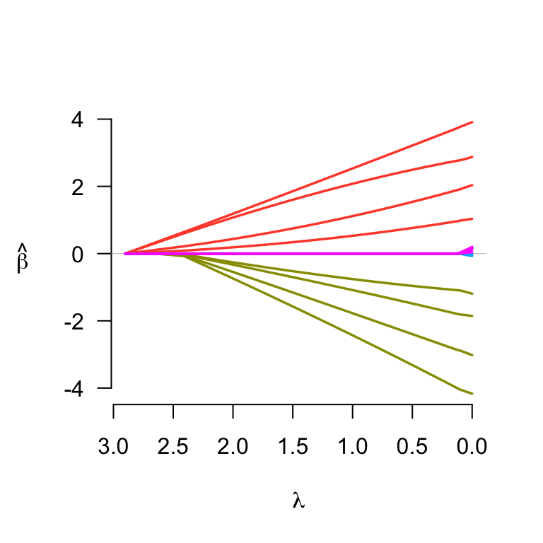

```r
path_Lasso <- grpreg(X, y, group, group.multiplier=K, penalty="grLasso")
path_MCP <- grpreg(X, y, group, group.multiplier=K, penalty="grMCP")
# We simply use the unexported function in 'grpreg' to plot the solution paths.
grpreg:::plot.grpreg(path_Lasso)
```

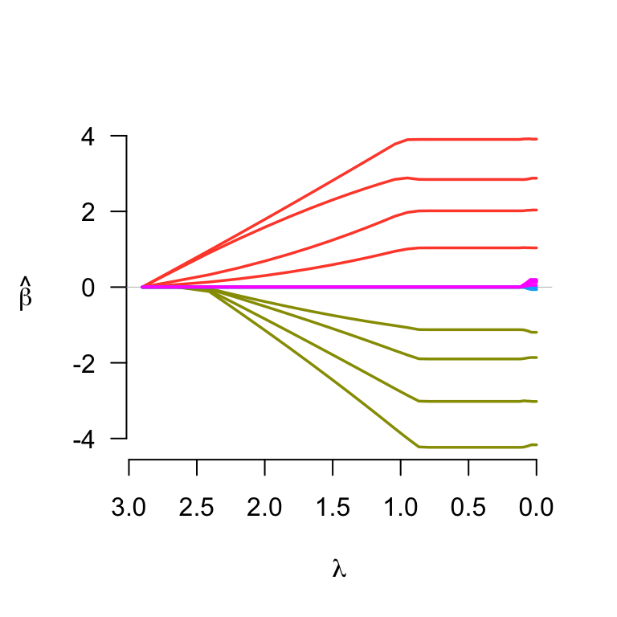

```r
grpreg:::plot.grpreg(path_MCP)
```

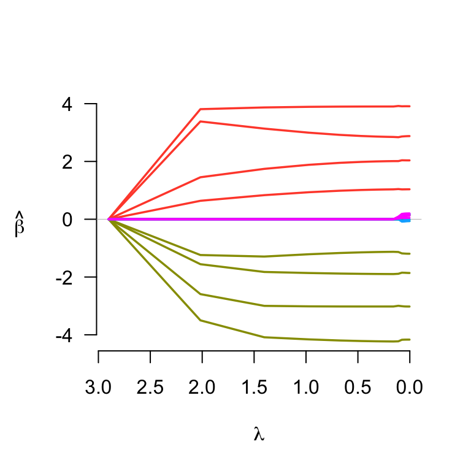

```r
grpreg:::plot.grpreg(path_GMC)
```

The solution path of group GMC is more flat than the other two, indicating its estimates are less shrunk and it's more robust against the tuning parameter selection. See Liu, Molstad, and Chi (2021) for more discussion.

## References

Liu, Xiaoqian, Aaron J Molstad, and Eric C Chi. 2021. “A Convex-Nonconvex Strategy for Grouped Variable Selection.” *arXiv Preprint arXiv:2111.15075*.

Selesnick, Ivan. 2017. “Sparse Regularization via Convex Analysis.” *IEEE Transactions on Signal Processing* 65 (17). IEEE: 4481–94.